# Fuelonomics: Analyzing Gas Price Dynamics through Machine Learning

Yimo Shen

2023-06-04

## Introduction

The fluctuating gas prices in the United States have a significant impact on the economy, transportation sector, and the daily lives of individuals. Understanding the factors that influence gas prices and accurately predicting their future values can provide valuable insights for policymakers, businesses, and consumers alike. In this project, we aim to investigate the determinants of gas prices in the U.S. and develop a predictive model using machine learning methodologies.

## Data

The project follows a structured approach, beginning with data collection. The project leverages data from two main sources: Statistical Review of World Energy published by BP, a reputable source for global energy economics, and the U.S. Energy information Administration. The first source provides data on energy prices, consumption, and production for a variety of sources of energy, like oil, natural gas, renewables etc. The second source provides data on prices of gasoline specifically. We analyzed data from the time period 1965-2021. Data from these sources provide a comprehensive information on global energy markets.

In the project analyzing the determinants of U.S. gas prices, data preparation played a crucial role in ensuring the reliability and accuracy of the analysis. The main data sources utilized were the Statistical Review of World Energy published by BP, a reputable source for global energy economics, and the U.S. Energy Information Administration. The initial dataset provided by BP contained data on various energy metrics from different countries. To narrow down the focus specifically to the U.S., all the relevant U.S. metrics were combined into a single dataset.

One important step in the data preparation process was addressing missing values. To fill in these missing values, alternative sources such as government websites were consulted. By cross-referencing and validating the missing values from different sources, the dataset’s completeness was improved, ensuring that crucial information was not overlooked or excluded from the analysis.

Furthermore, efforts were made to enhance the quality of the dataset by eliminating columns that exhibited perfect correlation or collinearity. This involved removing columns that represented the same metric but with different units and identifying and eliminating subcategories that added up to another column. This step reduced redundancy and improved the model’s robustness by avoiding multicollinearity issues, ensuring that each variable contributed unique and meaningful information to the analysis.

Overall, the data preparation process involved consolidating the relevant U.S. metrics, filling in missing values through extensive research, and removing redundant columns. These steps were crucial in creating a refined and reliable dataset for further analysis, setting the foundation for investigating the determinants of U.S. gas prices accurately and drawing meaningful insights from the data

## ML

Machine learning offers a powerful approach to investigate the determinants of gas prices in the United States and develop accurate predictive models. By leveraging vast amounts of historical data, machine learning algorithms can identify key features that influence gas prices, ultimately providing valuable insights for decision-making. This project’s analysis consists of two parts: feature selection and prediction. Two popular algorithms for feature selection in this context are Recursive Feature Elimination (RFE) and Lasso regression. RFE iteratively removes less relevant features, while Lasso regression performs variable selection by introducing a penalty term. Once the relevant features are identified, two effective algorithms for gas price prediction are Random Forest Regression (RFR) and Neural Network. RFR creates an ensemble of decision trees to make accurate predictions, while Neural Network models use interconnected layers of artificial neurons to learn complex patterns and relationships in the data. By comparing these algorithms and selecting the one with the best performance, machine learning can enable the investigation of gas price determinants and develop robust predictive models for future gas price predictions in the U.S.

### Feature Selection

Feature selection can bring several benefits, such as reducing overfitting, improving model training and inference speed, enhancing interpretability, and simplifying the underlying model.

#### Simple Linear Regression

The first feature selection algorithm our group decided to use was a simple linear regression. Linear regression can be a valuable tool for feature selection and exploring the determinants of U.S. gas prices. By fitting a linear model to the data, linear regression allows us to identify the relationships between the target variable (gas prices) and various predictor variables. Through the process of model building, linear regression estimates the coefficients of the predictor variables, indicating their impact on gas prices. This estimation process inherently performs feature selection by assigning higher coefficients to variables that have a stronger influence on gas prices, while reducing the importance of variables with little impact. By analyzing the coefficients, we can identify the key determinants of gas prices and understand their respective magnitudes and directions of effect. Linear regression also provides valuable insights into the statistical significance of the predictor variables, helping to distinguish between significant factors and random fluctuations. Thus, linear regression serves as a versatile tool for feature selection and uncovering the determinants of U.S. gas prices, enabling researchers to gain a deeper understanding of the factors driving price fluctuations in the market.

```r
model <- lm(log(data$US.Gasoline.Prices) ~ log(data$oil_production_bbl) + log(data$oil_crude_oil_prices) +
              data$oil_consumption_bbl + data$primary_energy_consumption_per_capital +
              log(data$renewables_generation_ej) + log(data$nuclear_energy_generation_twh) +
              log(data$hydroelectricity_generation_twh), data = data)
summary(model)
```

```
##
## Call:
## lm(formula = log(data$US.Gasoline.Prices) ~ log(data$oil_production_bbl) +
##     log(data$oil_crude_oil_prices) + data$oil_consumption_bbl +
##     data$primary_energy_consumption_per_capital + log(data$renewables_generation_ej) +
##     log(data$nuclear_energy_generation_twh) + log(data$hydroelectricity_generation_twh),
##     data = data)
##
## Residuals:
##      Min       1Q   Median       3Q      Max
## -0.37365 -0.07577  0.01371  0.08586  0.22503
##
## Coefficients:
##                                               Estimate Std. Error t value
## (Intercept)                                  5.875e+00  1.238e+00   4.744
## log(data$oil_production_bbl)                -6.440e-01  1.005e-01  -6.407
## log(data$oil_crude_oil_prices)               2.937e-01  4.354e-02   6.746
## data$oil_consumption_bbl                     2.523e-05  3.088e-05   0.817
## data$primary_energy_consumption_per_capital -7.317e-03  2.926e-03  -2.501
## log(data$renewables_generation_ej)           2.742e-01  6.374e-02   4.301
## log(data$nuclear_energy_generation_twh)      5.363e-02  4.570e-02   1.173
## log(data$hydroelectricity_generation_twh)    1.624e-01  1.794e-01   0.905
##                                             Pr(>|t|)
## (Intercept)                                 1.85e-05 ***
## log(data$oil_production_bbl)                5.51e-08 ***
## log(data$oil_crude_oil_prices)              1.64e-08 ***
## data$oil_consumption_bbl                      0.4179
## data$primary_energy_consumption_per_capital   0.0158 *
## log(data$renewables_generation_ej)          8.07e-05 ***
## log(data$nuclear_energy_generation_twh)       0.2463
## log(data$hydroelectricity_generation_twh)     0.3696
## ---
## Signif. codes:  0 '***' 0.001 '**' 0.01 '*' 0.05 '.' 0.1 ' ' 1
##
## Residual standard error: 0.1308 on 49 degrees of freedom
## Multiple R-squared:  0.9734, Adjusted R-squared:  0.9696
## F-statistic: 255.9 on 7 and 49 DF,  p-value: < 2.2e-16
```

#### LASSO

We then explored other feature selection algorithms that performs betetr than a simple linear regression, and ultimately settled on LASSO Regression. LASSO (Least Absolute Shrinkage and Selection Operator) regression offers several advantages over traditional linear regression for feature selection. It automatically selects relevant variables by shrinking some coefficients to zero, effectively eliminating irrelevant features from the model. LASSO handles multicollinearity by reducing coefficients of highly correlated variables, improving model stability. The sparsity induced by LASSO simplifies the model and enhances interpretability by highlighting the most important predictors. It also prevents overfitting by shrinking coefficients and promotes better generalization to unseen data. Furthermore, LASSO is flexible in handling large feature sets, making it suitable for high-dimensional datasets. These benefits make LASSO regression a powerful technique for feature selection, enhancing model interpretability, and improving predictive performance.

#### RFE

Another suitable algorithm for feature selection is Recursive Feature Elimination (RFE). RFE performs feature selection by iteratively eliminating the least informative features from a larger set of variables. It starts by training a model using all the features and ranks them based on their importance or contribution to the model’s performance. Then, the least important features are removed, and the process is repeated until the desired number of features is obtained. This iterative process allows RFE to identify the most relevant features that have the strongest impact on gas prices. By automatically selecting these influential factors, RFE helps uncover the underlying determinants of gas prices and improves the interpretability and accuracy of predictive models. Moreover, RFE addresses multicollinearity issues by considering the interdependencies among features, resulting in a subset of uncorrelated variables that provide unique information.

### Prediction

#### Visual Representation of Neural Network Performance

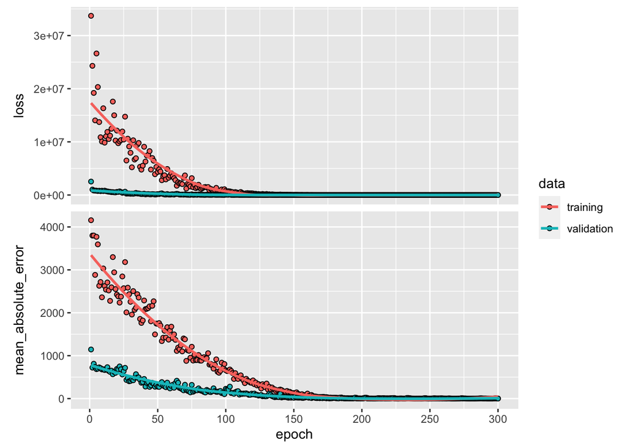

```r
library(ggplot2)
plot(history)
```

```r
## Predict from the final model and evaluate its performance on the test data
pred <- predict(modnn, x[testid,])
mean(abs(y[testid]-pred))  # mean absolute error, set.seed() may not guarantee reproducibility here
```

```
## [1] 0.6223379
```

#### Random Forrest/Decision Trees